# tcplfit2: A Concentration-Response Modeling Utility

## Exponential 4 (Exp4)

Model: $f(x) = tp*(1-2^{(-\frac{x}{ga})})$

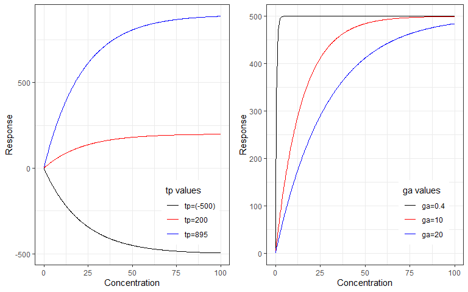

```r
fits_exp4 <- data.frame(
  # change tp
  y1 = exp4(ps = c(tp = 895,ga = 15),x = ex_conc),
  y2 = exp4(ps = c(tp = 200,ga = 15),x = ex_conc),
  y3 = exp4(ps = c(tp = -500,ga = 15),x = ex_conc),

  # change ga
  y4 = exp4(ps = c(tp = 500,ga = 0.4),x = ex_conc),
  y5 = exp4(ps = c(tp = 500,ga = 10),x = ex_conc),
  y6 = exp4(ps = c(tp = 500,ga = 20),x = ex_conc)

)

# shows how changes in parameter 'tp' affect the shape of the curve
exp4_plot1 <- ggplot(fits_exp4, aes(ex_conc)) +
  geom_line(aes(y = y1, color = "tp=895")) +
  geom_line(aes(y = y2, color = "tp=200")) +
  geom_line(aes(y = y3, color = "tp=(-500)")) +
  labs(x = "Concentration", y = "Response") +
  theme_bw()+
  theme(legend.position = c(0.8,0.2)) +
  scale_color_manual(name='tp values',
                     breaks=c('tp=(-500)', 'tp=200', 'tp=895'),
                     values=c('tp=(-500)'='black', 'tp=200'='red', 'tp=895'='blue'))


# shows how changes in parameter 'ga' affect the shape of the curve
exp4_plot2 <- ggplot(fits_exp4, aes(ex_conc)) +
  geom_line(aes(y = y4, color = "ga=0.4")) +
  geom_line(aes(y = y5, color = "ga=10")) +
  geom_line(aes(y = y6, color = "ga=20")) +
  labs(x = "Concentration", y = "Response") +
  theme_bw()+
  theme(legend.position = c(0.8,0.2)) +
  scale_color_manual(name='ga values',
                     breaks=c('ga=0.4', 'ga=10', 'ga=20'),
                     values=c('ga=0.4'='black', 'ga=10'='red', 'ga=20'='blue'))


grid.arrange(exp4_plot1, exp4_plot2, ncol = 2)
```

**Figure 31:** The left plot illustrates how changing `tp` (maximal change in response) affects the shape of the resulting exponential 4 curves while holding `ga` constant ($ga = 15$). The right plot illustrates how changing `ga` (slope) affects the shape of the resulting exponential 4 curves while holding `tp` constant ($tp = 500$).

## Exponential 5 (Exp5)

Model: $f(x) = tp*(1-2^{(-(x/ga)^p)})$

Parameters include:

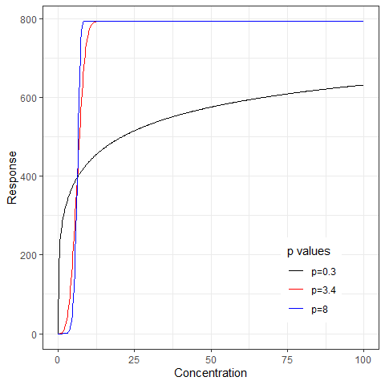

```r
fits_exp5 <- data.frame(
  # change p
  y1 = exp5(ps = c(tp = 793,ga = 6.25,p = 0.3), x = ex_conc),
  y2 = exp5(ps = c(tp = 793,ga = 6.25,p = 3.4), x = ex_conc),
  y3 = exp5(ps = c(tp = 793,ga = 6.25,p = 8), x = ex_conc)

)

# shows how changes in parameter 'p' affect the shape of the curve
exp5_plot <- ggplot(fits_exp5, aes(ex_conc)) +
  geom_line(aes(y = y1, color = "p=0.3")) +
  geom_line(aes(y = y2, color = "p=3.4")) +
  geom_line(aes(y = y3, color = "p=8")) +
  labs(x = "Concentration", y = "Response") +
  theme_bw()+
  theme(legend.position = c(0.8,0.2)) +
  scale_color_manual(name='p values',
                     breaks=c('p=0.3', 'p=3.4', 'p=8'),
                     values=c('p=0.3'='black', 'p=3.4'='red', 'p=8'='blue'))

exp5_plot
```

**Figure 32:** This plot illustrates how changing `p` (power) affects the shape of the resulting exponential 5 curves while holding all other parameters constant ($tp = 793, ga = 6.25$).

## Table of All Model Details

This table provides a summary of model details for all available `tcplfit2` models. This table is taken from the Concentration-Response Modeling Details sub-section in the [`tcpl` Vignette on CRAN](https://cran.R-project.org/package=tcpl).

[output not shown]

Model descriptions are pulled from tcplFit2 manual at https://cran.R-project.org/package=tcplfit2.

# Glossary

The following glossary, though it may not be encompassing all terms included in this package, is provided to serve as a quick reference when using `tcplfit2`:

**a**

Model fitting parameter in the following models: exp2, exp3, poly1, poly2, pow

**ac5**

Active concentration at 5% of the maximal predicted change in response (top) value

**ac10**

Active concentration at 10% of the maximal predicted change in response (top) value

**ac20**

Active concentration at 20% of the maximal predicted change in response (top) value

**ac50**

Active concentration at 50% of the maximal predicted change in response (top) value

**acc**

Active concentration at the cutoff

**ac1sd**

Active concentration at 1 standard deviation of the baseline response

**b**

Model fitting parameter in the following models: exp2, exp3, ploy2

**bmad**

Baseline median absolute deviation. Measure of baseline variability.

**bmed**

Baseline median response. If set to zero then the data are already zero-centered. Otherwise, this value is used to zero-center the data by shifting the entire response series by the specified amount.

**bmd**

Benchmark dose, activity concentration observed at the benchmark response (BMR) level

**bmdl**

Benchmark dose lower confidence limit. Derived using a 90% confidence interval around the BMD to reflect the uncertainty

**bmdu**

Benchmark dose upper confidence limit. Derived using a 90% confidence interval around the BMD to reflect the uncertainty

**bmr**

Benchmark response. Response level at which the BMD is calculated as $BMR = {\text{onesd}}\times{\text{bmr_scale}}$, where the default `bmr_scale` is 1.349

**caikwt**

Akaike weight of the constant model relative to the winning model, calculated as $\frac{exp(0.5*AIC_{constant})}{exp(0.5*AIC_{constant})+exp(0.5*AIC_{winning})}$. Used in calculating the continuous hitcall.

**conc**

Tested concentrations, typically micromolar ($\mu M$)

**cutoff**

Efficacy threshold. User-specified to define activity and may reflect statistical, assay-specific, and biological considerations

**er**

Model fitting error parameter, measure of the uncertainty in parameters used to define the model and plotting error bars

**fit_method**

Curve fit method

**ga**

AC50 for the rising curve in a Hill model or the gnls model

**hitc or hitcall**

Continuous hitcall value ranging from 0 to 1

**mll**

Maximum log-likelihood of winning model. Used in calculating the continuous hitcall $length(modpars) - aic(fit_{method})/2$

**la**

AC50 for the falling curve in a gain-loss model

**lc50**

Loss concentration at 50% of maximal predicted change in response (top), corresponding to the loss side of the gnls model

**n_gt_cutoff**

Number of data points above the cutoff

**p**

Model fitting parameter in the following models: exp3, exp5, gnls, Hill, pow

**q**

Model fitting parameter in the gnls model

**resp**

Observed responses at respective concentrations (conc)

**rmse**

Root mean square error of the data points relative to model fit. Lower RMSE indicate model fits the data well.

**top_over_cutoff**

Ratio of the maximal predicted change in response from baseline value to the cutoff (top/cutoff)

**top**

Response value at the maximal predicted change in response from baseline ($y = 0$)

**tp**

Model fitting parameter in the following models: Hill, gnls, exp4, exp5 - the horizontal asymptote that the predicted curve is approaching (theoretical maximum)